# Practical: Directed acyclic graphs and confounding

Tom Palmer

## Refresher

Notation: exposure $X$, outcome $Y$

- Pathway

[interactive chart not shown]

- Mediator:

[interactive chart not shown]

- Backdoor pathway (first arrow goes wrong way from start point): $X$–$L$–$Y$

[interactive chart not shown]

- Collider

[interactive chart not shown]

A pathway is closed if

- Adjust for a variable that’s not a collider on the pathway
- There’s a collider on the pathway

## Question 1

These questions were inspired by material given by Prof M. A. Hernan.

### a)

What is the triangle definition of a confounder – it has three criteria

[interactive chart not shown]

A confounder is

1. associated with the exposure
2. associated with the outcome conditional on the exposure
3. not on the causal pathway between the exposure and outcome

### b)

What is Pearl’s definition of confounding?

There is confounding of the exposure and outcome relationship when there is an open backdoor pathway between them (therefore, a confounder is any variable on an open backdoor pathway between an exposure and outcome.)

### c)

For each of the following DAGs assess whether

- $L$ is confounder under the triangle definition of a confounder (assess each of the 3 criteria)
- and whether there is confounding under Pearl’s definition

#### DAG A

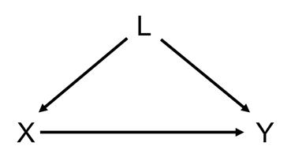

- Triangle definition:
  1. Yes, $L$ is associated with the exposure, $L$–$X$
  2. Yes, $L$ is associated with the outcome conditional upon the exposure, $L$–$Y$
  3. Yes, $L$ is not on the causal pathway between the exposure and outcome  
     Overall: Yes, $L$ is a confounder
- Pearl: Yes, there is confounding since $X$–$L$–$Y$ is an open backdoor pathway

#### DAG B

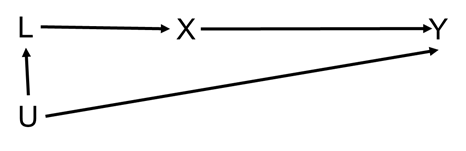

- Triangle definition:
  1. Yes, $L$ is associated with the exposure, $L$–$X$
  2. Yes, $L$ is associated with the outcome conditional upon the exposure, $L$–$U$–$Y$
  3. Yes, $L$ is not on the causal pathway between the exposure and outcome  
     Overall: Yes, $L$ is a confounder
- Pearl: Yes there is confounding of $X$–$Y$ relationship because $X$–$L$–$U$–$Y$ is an open backdoor pathway

#### DAG C

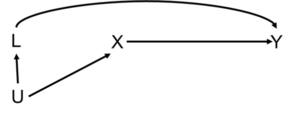

- Triangle definition:
  1. Yes, $L$ is associated with the exposure, $L$–$U$–$X$
  2. Yes, $L$ is associated with the outcome conditional upon the exposure, $L$–$Y$
  3. Yes, $L$ is not on the causal pathway between the exposure and outcome  
     Overall: Yes, $L$ is a confounder
- Pearl: Yes there is confounding of the $X$–$Y$ relationship because $X$–$U$–$L$–$Y$ is an open backdoor pathway.

#### DAG D

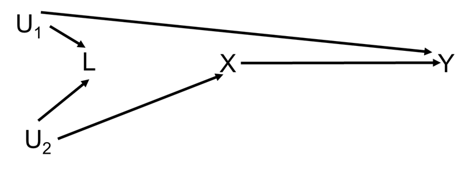

- Triangle definition:
  1. Yes, $L$ is associated with the exposure, $L$–$U_2$–$X$ is an open path
  2. Yes, $L$ is associated with the outcome conditional upon the exposure, $L$–$U_1$–$Y$ is an open path
  3. Yes, $L$ is not on the causal pathway between $X$ and $Y$  
     Overall: Yes, $L$ is a confounder
- Pearl: **No**! There is no confounding of the $X$–$Y$ relationship because $X$–$U_2$–$L$–$U_1$–$Y$ is a closed pathway. Under *d*-separation (directional-separation) rules $L$ is a collider of $U_1$ and $U_2$. Hence, without adjustment for the $L$ the path is closed. Including $L$ in a model will open the path between $U_1$ and $U_2$ which would bias the association between $X$ and $Y$, since $X$–$U_2$–$U_1$–$Y$ would be an open backdoor path. Hence, under the *d*-separation rules we don’t want to adjust for $L$, even though we consider it to be a confounder under the triangle definition.

*Takeaway message: the triangle definition of a confounder breaks down when there is a collider on a backdoor pathway*

## Question 2

The following DAG describes a model between an exposure ($E$), a disease outcome ($D$), and three other variables ($A$, $B$, and $C$).

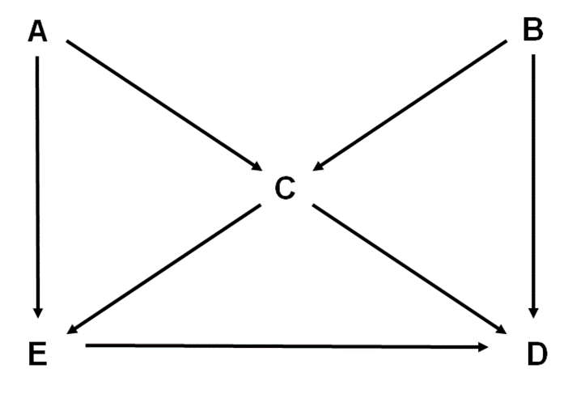

### a)

List all the (both open and closed) backdoor pathways between $E$ and $D$.

- $E$–$C$–$D$
- $E$–$C$–$B$–$D$
- $E$–$A$–$C$–$D$
- $E$–$A$–$C$–$B$–$D$

### b)

With respect to $A$ and $B$ how would you describe $C$?

$C$ is a collider with respect to $A$ and $B$.

### c)

If we fitted a regression model using $B$ as the outcome regressed on covariates $A$ and $C$, what could be the problem?

Since $C$ is a collider of $A$ and $B$, fitting such a model would be biased due to adjustment for a collider.

### d)

Suppose we want to estimate the effect of $E$ on $D$, is there one best model to estimate this association? Write down the best model/s

There are several models which block all potential backdoor pathways. These are:

- Adjusting for $C$ and $A$
- Adjusting for $C$ and $B$
- Adjusting for $C$ and $A$ and $B$

Given that we must include in $C$ we must then include one or both of $A$ and $B$ to block the $A$–$B$ pathway which is opened by adjusting for $C$.

There’s an argument to be made for adjusting for no variables as the bias induced by adjusting for $C$ could be worse than the $X$–$C$–$Y$ pathway.

### e)

Verify your answers using the **dagitty**/**ggdag** packages in R (or the dagitty web app [here](http://dagitty.net/dags.html)).

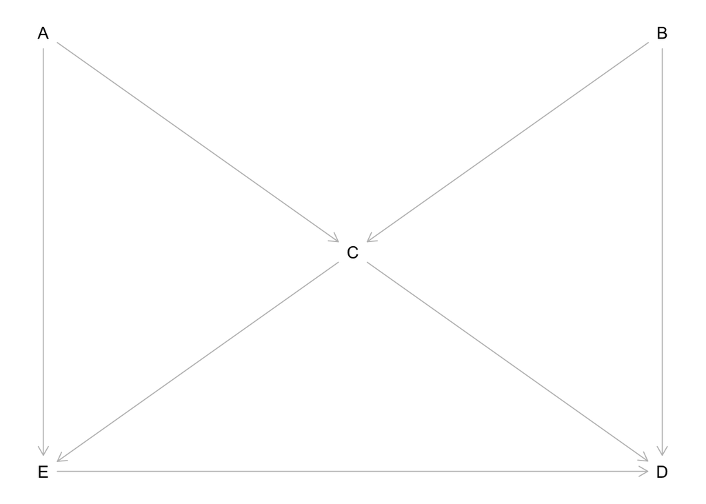

```r
library(dagitty)
library(ggdag)
theme_set(theme_dag())

g <- dagitty('dag {
  E <- A -> C <- B -> D
  E -> D
  C -> E
  C -> D
  E [exposure, pos="0,2"]
  D [outcome, pos="2,2"]
  A [pos="0,0"]
  B [pos="2,0"]
  C [pos="1,1"]
}')
plot(g)
```

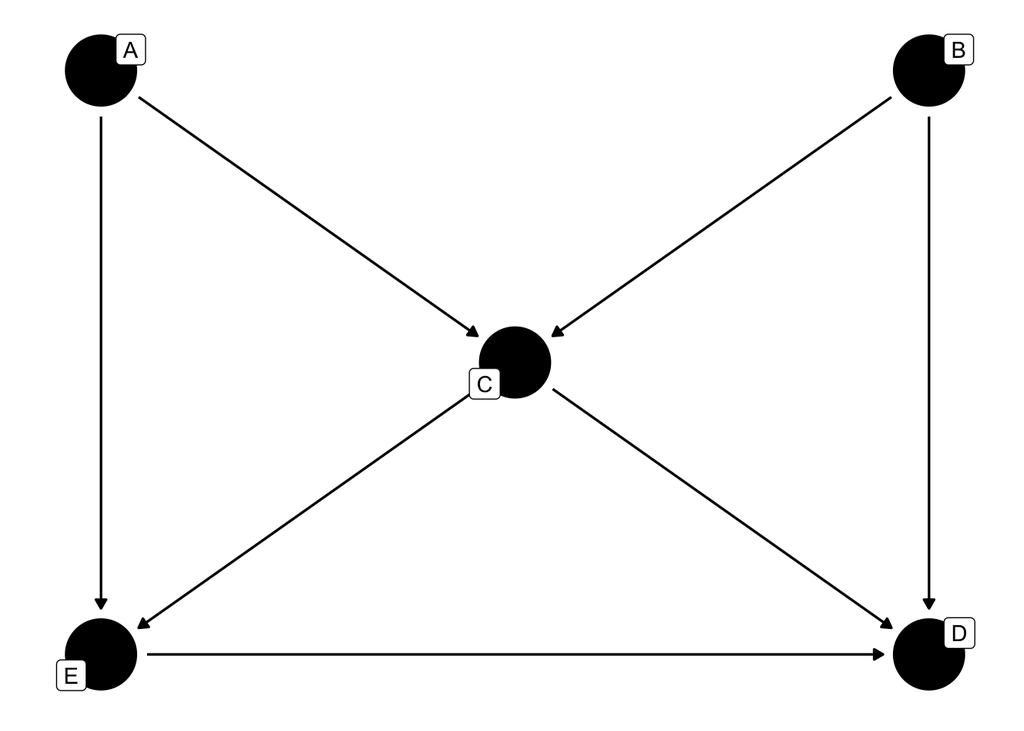

```r
library(ggdag)
theme_set(theme_dag())

butterfly_bias(x = "E", y = "D", a = "A", m = "C", b = "B",
               x_y_associated = TRUE) %>%
  ggdag(use_labels = "label", text = FALSE)
```

```r
paths(g, "E", "D")
```

```
## $paths
## [1] "E -> D"                "E <- A -> C -> D"      "E <- A -> C <- B -> D"
## [4] "E <- C -> D"           "E <- C <- B -> D"
##
## $open
## [1]  TRUE  TRUE FALSE  TRUE  TRUE
```

Which paths remain open when conditioning on C.

```r
paths(g, "E", "D", c("C"))
```

```
## $paths
## [1] "E -> D"                "E <- A -> C -> D"      "E <- A -> C <- B -> D"
## [4] "E <- C -> D"           "E <- C <- B -> D"
##
## $open
## [1]  TRUE FALSE  TRUE FALSE FALSE
```

```r
impliedConditionalIndependencies(g)
```

```
## A _||_ B
## A _||_ D | B, C, E
## B _||_ E | A, C
```

What do we need to adjust for to estimate the effect of E on D?

```r
adjustmentSets(g)
```

```
## { B, C }
## { A, C }
```

*Important: dagitty misses the third solution:* `{ A, B, C }`

## Applied example

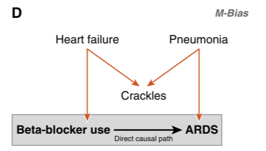

- The orange arrows represent a closed back-door path: chronic beta-blocker therapy $\leftarrow$ heart failure $\rightarrow$ Crkles $\leftarrow$ Pneumonia $\rightarrow$ acute respiratory distress syndrome (ARDS).
- Crackles stands for auscultatory crackles: https://en.wikipedia.org/wiki/Crackles
- Crackles is a collider that naturally leaves the back-door path closed. However, control for crackles would open the back-door path, introducing confounding through the path (beta-blocker – heart failure – pneumonia – ARDS).
- M-bias: bias induced by adjusting for a variable on a backdoor pathway which is a collider on that pathway.

We can modify the DAG to show that we don’t need to adjust under an M structure.

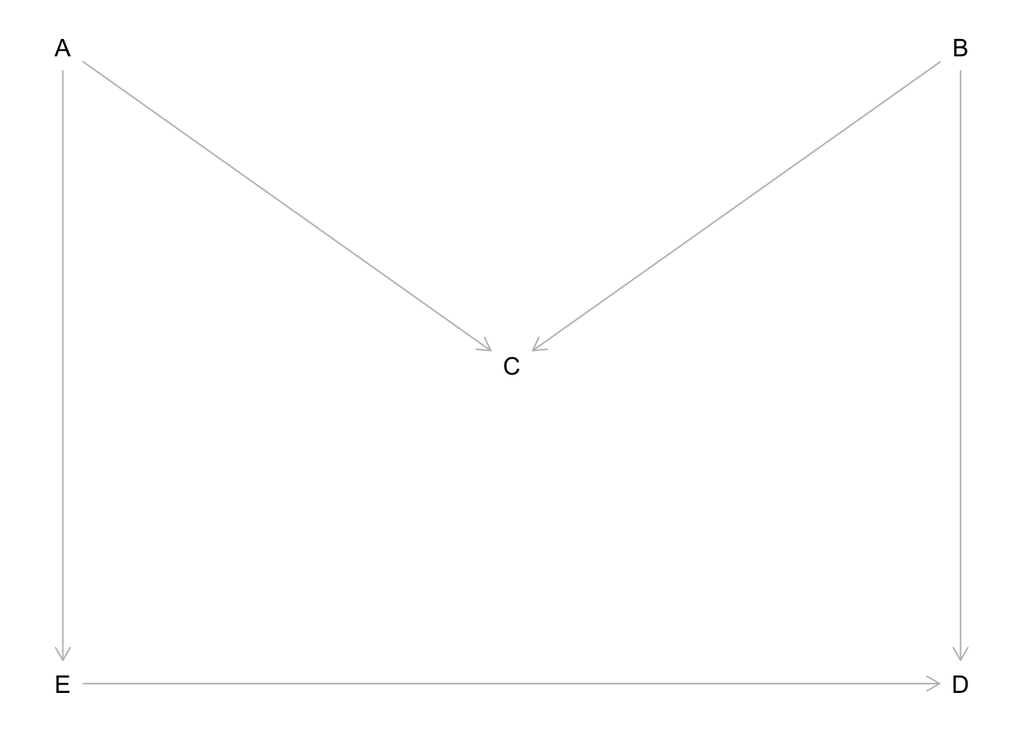

```r
g2 <- dagitty('dag {
  E <- A -> C <- B -> D
  E -> D
  E [exposure, pos="0,2"]
  D [outcome, pos="2,2"]
  A [pos="0,0"]
  B [pos="2,0"]
  C [pos="1,1"]
}')
plot(g2)
```

```r
adjustmentSets(g2)
```

```
##  {}
```

The adjustment set is the empty set, i.e., don’t adjust for any covariates.